# Travel Package Purchase Prediction - Solution

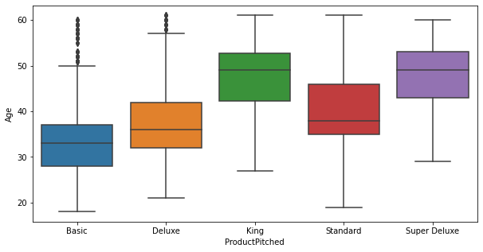

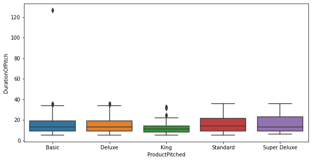

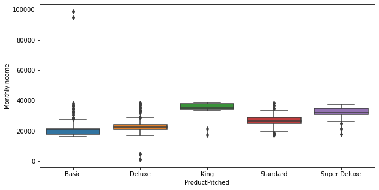

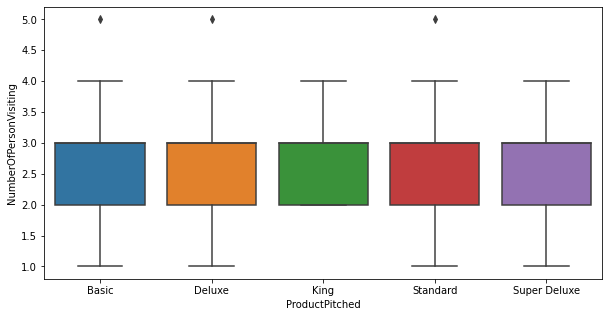

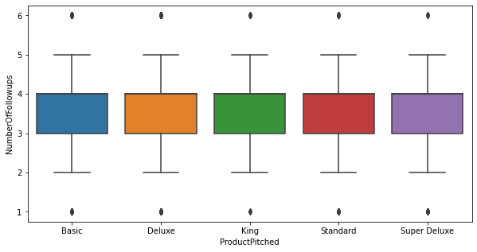

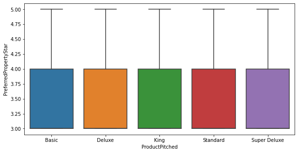

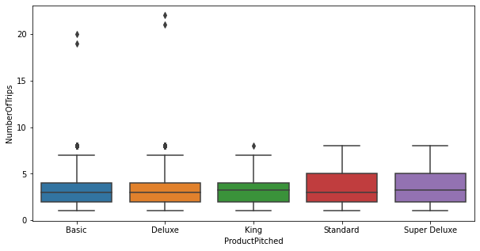

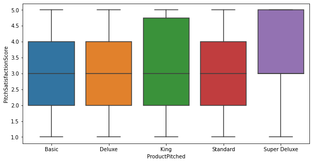

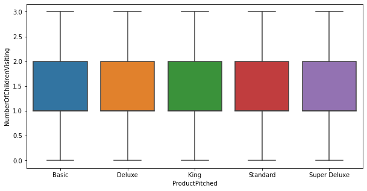

```
ProductPitched   Basic  Deluxe  King  Standard  Super Deluxe   All
TypeofContact
All               1842    1732   230       742           342  4888
Self Enquiry      1326    1191   182       524           246  3469
Company Invited    516     541    48       218            96  1419
------------------------------------------------------------------------------------------------------------------------
```

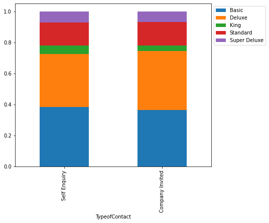

```
ProductPitched  Basic  Deluxe  King  Standard  Super Deluxe   All
CityTier
All              1842    1732   230       742           342  4888
1                1466     908   168       436           212  3190
3                 268     784    40       288           120  1500
2                 108      40    22        18            10   198
------------------------------------------------------------------------------------------------------------------------
```

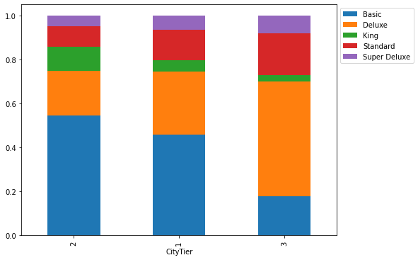

```
ProductPitched  Basic  Deluxe  King  Standard  Super Deluxe   All
Occupation
All              1842    1732   230       742           342  4888
Salaried          924     818   114       338           174  2368
Small Business    720     790   104       320           150  2084
Large Business    196     124    12        84            18   434
Free Lancer         2       0     0         0             0     2
------------------------------------------------------------------------------------------------------------------------
```

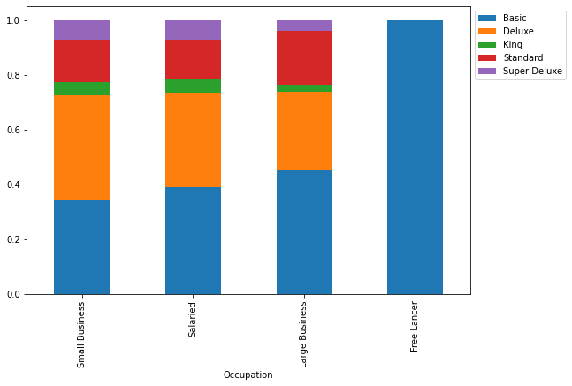

```
ProductPitched  Basic  Deluxe  King  Standard  Super Deluxe   All
Gender
All              1842    1732   230       742           342  4888
Male             1162    1008   148       416           182  2916
Female            680     724    82       326           160  1972
------------------------------------------------------------------------------------------------------------------------
```

[5 more figures not shown]

```python
for column in corr_cols:
    plt.figure(figsize=(10, 5))
    sns.boxplot(x="ProductPitched", y=column, data=data)
    plt.show()

columns=data.select_dtypes(include=["object", "category"]).columns.tolist()

pred_features = ['TypeofContact', 'CityTier','Occupation', 'Gender',
             'MaritalStatus', 'Passport', 'OwnCar','Designation']
target = 'ProductPitched'
for predictor in pred_features:
    stacked_barplot(data, predictor, target)
```

#### Profile for the Travel Packages

`Basic`:

`Miscellaneous Info`:

- Free Lancers go for Basic package. But the data is very limited to make this conclusion.
- More than 70% of the Small/Large Business and salaried people mostly go for Basic and Deluxe packages.
- Gender wise both Basic and Deluxe are popular.
- Single people mosly prefer Basic
- Unmarried people prefer Deluxe.Basic and Standard are also popular next.

### Summary of EDA

#### Data Description

- The dataset has 4888 rows and 20 columns
- There is a even mix of int, float and object data types.
- There are missing values in the dataset in columns like DurationOfPitch,MonthlyIncome,Age,NumberOfTrips, etc. which are imputed accordingly.
- Dependent variable is ProdTaken.

#### Data Cleaning

- `CustomerID`: The ID attribute does not add any information to our analysis as all the values are unique. There is no association between a person's customer ID and if he will buy the travel package. We will drop this feature.
- There is a high correlation between `NumberOfPersonsVisiting` and `NumberOfChildrenVisiting`. So we can drop one of them. In this case we will drop `NumberOfChildrenVisiting`.

### Observations

`Age`:

- Average age of customers is 37 years, age of customers has a wide range from 18 to 61 years.
- The distribution of Age is fairly symmetrical about the mean and the median.

`MonthlyIncome`:

- Average income of customers is 23k dollars. Income has a wide range from 1k dollars to 98k dollars.
- The distribution of Income is skewed to right.
- 50% of the customers have income less than 22k dollars.

`DurationOfPitch`:

- The average duration of the pitch given by a salesperson to a customer is 15.
- The distribution of DurationOfPitch is skewed to the right and there are many outliers.
- 50% of the customers were given pitch of duration less than 13.

`NumberOfTrips`:

- Average number of trips in a year by a customer is 3
- Most customers (~75%) travel up to 4 times a year but there are some outliers.

`NumberOfFollowUps`:

- Average number of follow ups by the salesperson after the initial pitch is 4, with this number ranging from 1 to 6.
- 75% of the customers were followed up for around 4 times but there are some outliers.

`NumberOfPersonsVisiting`:

- Average number of persons planning to take the trip with the customer is 3, with a range between 1 to 5.
- 75% of the customers have up to 3 people planning to take trip with them.

`NumberOfPersonsVisiting`:

- The average number of children < 5 years taking the trip with the customer is 1, with a range from 0 - 3.
- 75% of the customers have up to 2 children accompanying them.

`PreferredPropertyStar` and `PitchSatisfactionScore`:

  ```
    Basic > Standard > Deluxe > King > Super Deluxe
  ```

- Around 48% of the customers are married. However, Single and unmarried purchased more compared to Married and Divorced.
- Around 70% of the customers don't have a passport. However, the customers who have passport tend to purchase the package more compared to without passport.
- 38% of the customers are executives and the other 35% are Managers. Executives followed by Mangers are the ones who purchased the most.

##### Dropping columns that are no more required

```python
data.drop(cols_to_log, axis=1, inplace=True)
data.drop('NumberOfChildrenVisiting', axis=1, inplace=True)
data.head()
```

|  | ProdTaken | Age | TypeofContact | CityTier | Occupation | Gender | NumberOfPersonVisiting | NumberOfFollowups | ProductPitched | PreferredPropertyStar | MaritalStatus | NumberOfTrips | Passport | PitchSatisfactionScore | OwnCar | Designation | DurationOfPitch_log | MonthlyIncome_log |
| --- | --- | --- | --- | --- | --- | --- | --- | --- | --- | --- | --- | --- | --- | --- | --- | --- | --- | --- |
| 0 | 1 | 41.0 | Self Enquiry | 3 | Salaried | Female | 3 | 3.0 | Deluxe | 3.0 | Single | 1.0 | 1 | 2 | 1 | Manager | 1.945910 | 9.951992 |
| 1 | 0 | 49.0 | Company Invited | 1 | Salaried | Male | 3 | 4.0 | Deluxe | 4.0 | Divorced | 2.0 | 0 | 3 | 1 | Manager | 2.708050 | 9.910016 |
| 2 | 1 | 37.0 | Self Enquiry | 1 | Free Lancer | Male | 3 | 4.0 | Basic | 3.0 | Single | 7.0 | 1 | 3 | 0 | Executive | 2.197225 | 9.746307 |
| 3 | 0 | 33.0 | Company Invited | 1 | Salaried | Female | 2 | 3.0 | Basic | 3.0 | Divorced | 2.0 | 1 | 5 | 1 | Executive | 2.302585 | 9.793114 |
| 4 | 0 | 36.0 | Self Enquiry | 1 | Small Business | Male | 2 | 3.0 | Basic | 4.0 | Divorced | 1.0 | 0 | 5 | 1 | Executive | 2.197225 | 9.823849 |

```python
# Separating features and the target column
X = data.drop(['ProdTaken'], axis=1)
y = data['ProdTaken']
```

```python
X = pd.get_dummies(
    X,
    columns=data.select_dtypes(include=["object", "category"]).columns.tolist(),
    drop_first=True,
)

X.head()
```

|  | Age | NumberOfPersonVisiting | NumberOfFollowups | PreferredPropertyStar | NumberOfTrips | PitchSatisfactionScore | DurationOfPitch_log | MonthlyIncome_log | TypeofContact_Self Enquiry | CityTier_2 | ... | ProductPitched_Super Deluxe | MaritalStatus_Married | MaritalStatus_Single | MaritalStatus_Unmarried | Passport_1 | OwnCar_1 | Designation_Executive | Designation_Manager | Designation_Senior Manager | Designation_VP |
| --- | --- | --- | --- | --- | --- | --- | --- | --- | --- | --- | --- | --- | --- | --- | --- | --- | --- | --- | --- | --- | --- |
| 0 | 41.0 | 3 | 3.0 | 3.0 | 1.0 | 2 | 1.945910 | 9.951992 | 1 | 0 | ... | 0 | 0 | 1 | 0 | 1 | 1 | 0 | 1 | 0 | 0 |
| 1 | 49.0 | 3 | 4.0 | 4.0 | 2.0 | 3 | 2.708050 | 9.910016 | 0 | 0 | ... | 0 | 0 | 0 | 0 | 0 | 1 | 0 | 1 | 0 | 0 |
| 2 | 37.0 | 3 | 4.0 | 3.0 | 7.0 | 3 | 2.197225 | 9.746307 | 1 | 0 | ... | 0 | 0 | 1 | 0 | 1 | 0 | 1 | 0 | 0 | 0 |
| 3 | 33.0 | 2 | 3.0 | 3.0 | 2.0 | 5 | 2.302585 | 9.793114 | 0 | 0 | ... | 0 | 0 | 0 | 0 | 1 | 1 | 1 | 0 | 0 | 0 |
| 4 | 36.0 | 2 | 3.0 | 4.0 | 1.0 | 5 | 2.197225 | 9.823849 | 1 | 0 | ... | 0 | 0 | 0 | 0 | 0 | 1 | 1 | 0 | 0 | 0 |

5 rows × 28 columns

```python
X.info()
```

```
<class 'pandas.core.frame.DataFrame'>
RangeIndex: 4888 entries, 0 to 4887
Data columns (total 28 columns):
 #   Column                       Non-Null Count  Dtype
---  ------                       --------------  -----
 0   Age                          4888 non-null   float64
 1   NumberOfPersonVisiting       4888 non-null   int64
 2   NumberOfFollowups            4888 non-null   float64
 3   PreferredPropertyStar        4888 non-null   float64
 4   NumberOfTrips                4888 non-null   float64
 5   PitchSatisfactionScore       4888 non-null   int64
 6   DurationOfPitch_log          4888 non-null   float64
 7   MonthlyIncome_log            4888 non-null   float64
 8   TypeofContact_Self Enquiry   4888 non-null   uint8
 9   CityTier_2                   4888 non-null   uint8
```

[output cut: 20 more lines]

```python
x_train, x_test, y_train, y_test = train_test_split(X, y, test_size=0.3, random_state=1)
```

```python
print("Number of rows in train data =", x_train.shape[0])
print("Number of rows in test data =", x_test.shape[0])
```

```
Number of rows in train data = 3421
Number of rows in test data = 1467
```

## Model evaluation criterion

### Which case is more important?

- Predicting that employee will not purchase the travel package but he actually does i.e. losing business.

### How to reduce this loss i.e need to reduce False Negatives?

- Company wants Recall to be maximized, greater the Recall higher the chances of minimizing false negatives. Hence, the focus should be on increasing Recall or minimizing the false negatives or in other words identifying the true positives(i.e. Class 1) so that the company can take measures to target the right customers and eventually increase the business.

```python
## Function to create confusion matrix
def make_confusion_matrix(model,y_actual,labels=[1, 0]):
    '''
    model : classifier to predict values of X
    y_actual : ground truth

    '''
    y_predict = model.predict(x_test)
    cm=metrics.confusion_matrix( y_actual, y_predict, labels=[0, 1])
    df_cm = pd.DataFrame(cm, index = [i for i in ["Actual - No","Actual - Yes"]],
                  columns = [i for i in ['Predicted - No','Predicted - Yes']])
    group_counts = ["{0:0.0f}".format(value) for value in
                cm.flatten()]
    group_percentages = ["{0:.2%}".format(value) for value in
                         cm.flatten()/np.sum(cm)]
    labels = [f"{v1}\n{v2}" for v1, v2 in
              zip(group_counts,group_percentages)]
    labels = np.asarray(labels).reshape(2,2)
    plt.figure(figsize = (10,7))
    sns.heatmap(df_cm, annot=labels,fmt='')
    plt.ylabel('True label')
    plt.xlabel('Predicted label')
```

```python
##  Function to calculate different metric scores of the model - Accuracy, Recall and Precision
def get_metrics_score(model,flag=True):
    '''
    model : classifier to predict values of X

    '''
    # defining an empty list to store train and test results
    score_list=[]

    #Predicting on train and tests
    pred_train = model.predict(x_train)
    pred_test = model.predict(x_test)

    #Accuracy of the model
    train_acc = model.score(x_train,y_train)
    test_acc = model.score(x_test,y_test)

    #Recall of the model
    train_recall = metrics.recall_score(y_train,pred_train)
    test_recall = metrics.recall_score(y_test,pred_test)

    #Precision of the model
    train_precision = metrics.precision_score(y_train,pred_train)
    test_precision = metrics.precision_score(y_test,pred_test)

    #ROC-AUC of the model
    train_roc_auc = metrics.roc_auc_score(y_train,pred_train)
    test_roc_auc = metrics.roc_auc_score(y_test,pred_test)

    score_list.extend((train_acc,test_acc,train_recall,test_recall,train_precision,test_precision,train_roc_auc,test_roc_auc))

    # If the flag is set to True then only the following print statements will be dispayed. The default value is set to True.
    if flag == True:
        print("Accuracy on training set : ",model.score(x_train,y_train))
        print("Accuracy on test set : ",model.score(x_test,y_test))
        print("Recall on training set : ",metrics.recall_score(y_train,pred_train))
        print("Recall on test set : ",metrics.recall_score(y_test,pred_test))
        print("Precision on training set : ",metrics.precision_score(y_train,pred_train))
        print("Precision on test set : ",metrics.precision_score(y_test,pred_test))
        print("ROC-AUC on training set : ",metrics.roc_auc_score(y_train,pred_train))
        print("ROC-AUC on test set : ",metrics.roc_auc_score(y_test,pred_test))

    return score_list # returning the list with train and test scores
```

```python
#base_estimator for bagging classifier is a decision tree by default
bagging_estimator=BaggingClassifier(random_state=1)
bagging_estimator.fit(x_train,y_train)
```

```
BaggingClassifier(random_state=1)
```

```python
#Using above defined function to get accuracy, recall and precision on train and test set
bagging_estimator_score=get_metrics_score(bagging_estimator)
```

```
Accuracy on training set :  0.9956153171587255
Accuracy on test set :  0.9079754601226994
Recall on training set :  0.9775641025641025
Recall on test set :  0.6182432432432432
Precision on training set :  0.9983633387888707
Precision on test set :  0.8926829268292683
ROC-AUC on training set :  0.9886032883217367
ROC-AUC on test set :  0.7997279410067625
```

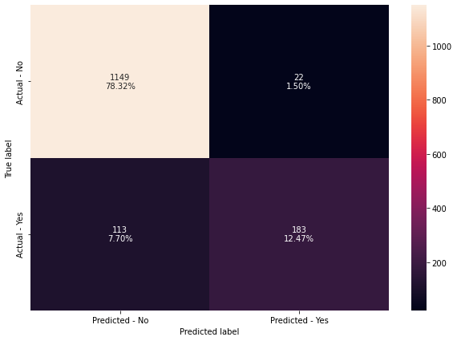

```python
make_confusion_matrix(bagging_estimator,y_test)
```

```python
# Choose the type of classifier.
bagging_estimator_tuned = BaggingClassifier(random_state=1)

# Grid of parameters to choose from
## add from article
parameters = {'max_samples': [0.7,0.8,0.9,1],
              'max_features': [0.7,0.8,0.9,1],
              'n_estimators' : [10,20,30,40,50],
             }

# Type of scoring used to compare parameter combinations
acc_scorer = metrics.make_scorer(metrics.recall_score)

# Run the grid search
grid_obj = GridSearchCV(bagging_estimator_tuned, parameters, scoring=acc_scorer,cv=5)
grid_obj = grid_obj.fit(x_train, y_train)

# Set the clf to the best combination of parameters
bagging_estimator_tuned = grid_obj.best_estimator_

# Fit the best algorithm to the data.
bagging_estimator_tuned.fit(x_train, y_train)
```

```
BaggingClassifier(max_features=0.9, max_samples=0.9, n_estimators=50,
                  random_state=1)
```

```python
#Using above defined function to get accuracy, recall and precision on train and test set
bagging_estimator_tuned_score=get_metrics_score(bagging_estimator_tuned)
```

```
Accuracy on training set :  0.9991230634317451
Accuracy on test set :  0.9188820722563054
Recall on training set :  0.9951923076923077
Recall on test set :  0.6317567567567568
Precision on training set :  1.0
Precision on test set :  0.949238578680203
ROC-AUC on training set :  0.9975961538461539
ROC-AUC on test set :  0.8116085235534425
```

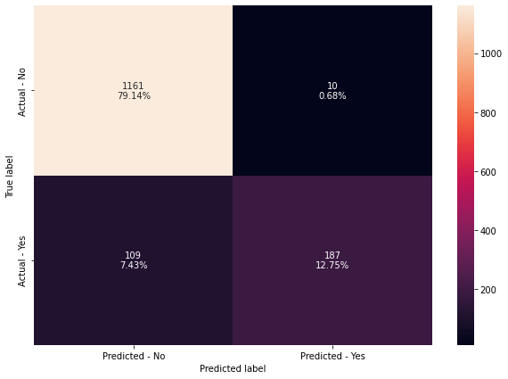

```python
make_confusion_matrix(bagging_estimator_tuned,y_test)
```

```python
bagging_lr=BaggingClassifier(base_estimator=LogisticRegression(solver='liblinear',random_state=1,max_iter=1000),random_state=1)
bagging_lr.fit(x_train,y_train)
```

```
BaggingClassifier(base_estimator=LogisticRegression(max_iter=1000,
                                                    random_state=1,
                                                    solver='liblinear'),
                  random_state=1)
```

```python
#Using above defined function to get accuracy, recall and precision on train and test set
bagging_lr_score=get_metrics_score(bagging_lr)
```

```
Accuracy on training set :  0.8459514761765565
Accuracy on test set :  0.830947511929107
Recall on training set :  0.296474358974359
Recall on test set :  0.2635135135135135
Precision on training set :  0.6776556776556777
Precision on test set :  0.7222222222222222
ROC-AUC on training set :  0.6325060389794926
ROC-AUC on test set :  0.6189471922819489
```

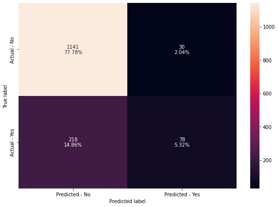

```python
make_confusion_matrix(bagging_lr,y_test)
```

```python
#Train the random forest classifier
rf_estimator=RandomForestClassifier(random_state=1)
rf_estimator.fit(x_train,y_train)
```

```
RandomForestClassifier(random_state=1)
```

```python
#Using above defined function to get accuracy, recall and precision on train and test set
rf_estimator_score=get_metrics_score(rf_estimator)
```

```
Accuracy on training set :  1.0
Accuracy on test set :  0.9086571233810498
Recall on training set :  1.0
Recall on test set :  0.5743243243243243
Precision on training set :  1.0
Precision on test set :  0.9550561797752809
ROC-AUC on training set :  1.0
ROC-AUC on test set :  0.7837462783022134
```

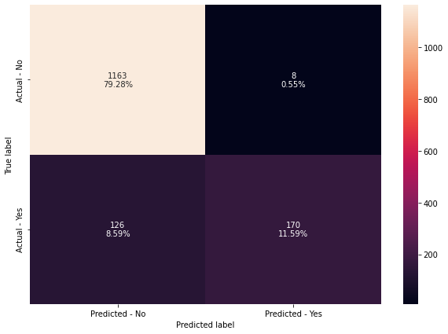

```python
make_confusion_matrix(rf_estimator,y_test)
```

```python
# Choose the type of classifier.
rf_estimator_tuned = RandomForestClassifier(random_state=1)

# Grid of parameters to choose from
## add from article
parameters = {"n_estimators": [150,200,250],
    "min_samples_leaf": np.arange(5, 10),
    "max_features": np.arange(0.2, 0.7, 0.1),
    "max_samples": np.arange(0.3, 0.7, 0.1),
             }

# Type of scoring used to compare parameter combinations
acc_scorer = metrics.make_scorer(metrics.recall_score)

# Run the grid search
grid_obj = GridSearchCV(rf_estimator_tuned, parameters, scoring=acc_scorer,cv=5)
grid_obj = grid_obj.fit(x_train, y_train)

# Set the clf to the best combination of parameters
rf_estimator_tuned = grid_obj.best_estimator_

# Fit the best algorithm to the data.
rf_estimator_tuned.fit(x_train, y_train)
```

```
RandomForestClassifier(max_features=0.6000000000000001,
                       max_samples=0.6000000000000001, min_samples_leaf=5,
                       n_estimators=200, random_state=1)
```

```python
#Using above defined function to get accuracy, recall and precision on train and test set
rf_estimator_tuned_score=get_metrics_score(rf_estimator_tuned)
```

```
Accuracy on training set :  0.9155217772581117
Accuracy on test set :  0.852760736196319
Recall on training set :  0.5641025641025641
Recall on test set :  0.35135135135135137
Precision on training set :  0.9539295392953929
Precision on test set :  0.8125
ROC-AUC on training set :  0.7790123117259334
ROC-AUC on test set :  0.6654280240958294
```

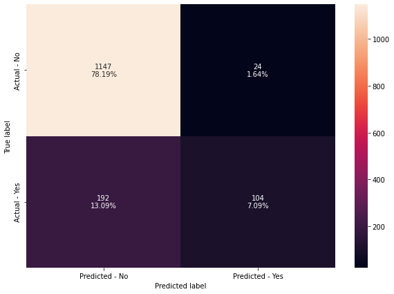

```python
make_confusion_matrix(rf_estimator_tuned,y_test)
```

```python
# Choose the type of classifier.
rf_estimator_weighted = RandomForestClassifier(random_state=1)

# Grid of parameters to choose from
## add from article
parameters = {
    "class_weight": [{0: 0.2, 1: 0.8}],
    "n_estimators": [100,150,200,250],
    "min_samples_leaf": np.arange(5, 10),
    "max_features": np.arange(0.2, 0.7, 0.1),
    "max_samples": np.arange(0.3, 0.7, 0.1),
}

# Type of scoring used to compare parameter combinations
acc_scorer = metrics.make_scorer(metrics.recall_score)

# Run the grid search
grid_obj = GridSearchCV(rf_estimator_weighted, parameters, scoring=acc_scorer,cv=5)
grid_obj = grid_obj.fit(x_train, y_train)

# Set the clf to the best combination of parameters
rf_estimator_weighted = grid_obj.best_estimator_

# Fit the best algorithm to the data.
rf_estimator_weighted.fit(x_train, y_train)
```

```
RandomForestClassifier(class_weight={0: 0.2, 1: 0.8},
                       max_features=0.4000000000000001,
                       max_samples=0.6000000000000001, min_samples_leaf=7,
                       random_state=1)
```

```python
#Using above defined function to get accuracy, recall and precision on train and test set
rf_estimator_weighted_score=get_metrics_score(rf_estimator_weighted)
```

```
Accuracy on training set :  0.9131832797427653
Accuracy on test set :  0.858214042263122
Recall on training set :  0.8333333333333334
Recall on test set :  0.597972972972973
Precision on training set :  0.729312762973352
Precision on test set :  0.6654135338345865
ROC-AUC on training set :  0.8821654153259445
ROC-AUC on test set :  0.7609847785445566
```

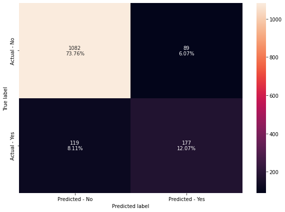

```python
make_confusion_matrix(rf_estimator_weighted,y_test)
```

[output not shown]

[output not shown]

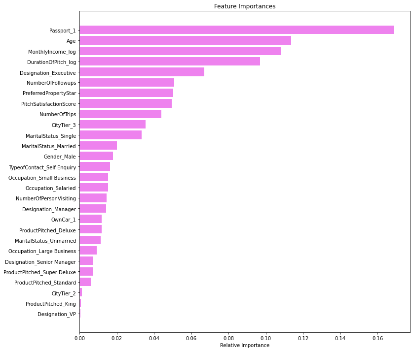

```python
importances = rf_estimator_weighted.feature_importances_
indices = np.argsort(importances)
feature_names = list(X.columns)

plt.figure(figsize=(12,12))
plt.title('Feature Importances')
plt.barh(range(len(indices)), importances[indices], color='violet', align='center')
plt.yticks(range(len(indices)), [feature_names[i] for i in indices])
plt.xlabel('Relative Importance')
plt.show()
```

## Decision Tree Model

```python
dt_estimator = DecisionTreeClassifier(criterion="gini", random_state=1)
dt_estimator.fit(x_train, y_train)
```

```
DecisionTreeClassifier(random_state=1)
```

```python
decision_tree_perf_score = get_metrics_score(dt_estimator)
```

```
Accuracy on training set :  1.0
Accuracy on test set :  0.901840490797546
Recall on training set :  1.0
Recall on test set :  0.7162162162162162
Precision on training set :  1.0
Precision on test set :  0.7794117647058824
ROC-AUC on training set :  1.0
ROC-AUC on test set :  0.8324889791584924
```

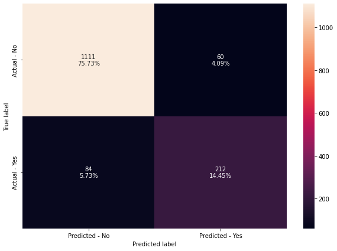

```python
make_confusion_matrix(dt_estimator,y_test)
```

[output not shown]

[output not shown]

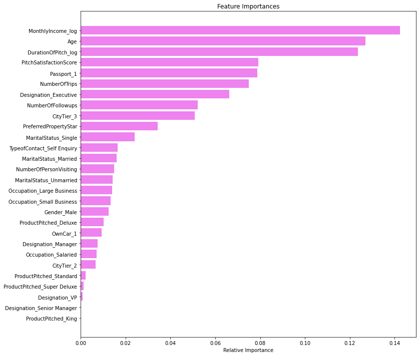

```python
importances = dt_estimator.feature_importances_
indices = np.argsort(importances)

plt.figure(figsize=(12, 12))
plt.title("Feature Importances")
plt.barh(range(len(indices)), importances[indices], color="violet", align="center")
plt.yticks(range(len(indices)), [feature_names[i] for i in indices])
plt.xlabel("Relative Importance")
plt.show()
```

### Hyperparameter Tuning

```python
# Choose the type of classifier.
dt_estimator_tuned = DecisionTreeClassifier(random_state=1)

# Grid of parameters to choose from

parameters = {
    "max_depth": [np.arange(2, 50, 5), None],
    "criterion": ["entropy", "gini"],
    "splitter": ["best", "random"],
    "min_impurity_decrease": [0.000001, 0.00001, 0.0001],
}

# Type of scoring used to compare parameter combinations
acc_scorer = make_scorer(recall_score)

# Run the grid search
grid_obj = GridSearchCV(dt_estimator_tuned, parameters, scoring=acc_scorer, cv=5)
grid_obj = grid_obj.fit(x_train, y_train)

# Set the clf to the best combination of parameters
dt_estimator_tuned = grid_obj.best_estimator_

# Fit the best algorithm to the data.
dt_estimator_tuned.fit(x_train, y_train)
```

```
DecisionTreeClassifier(criterion='entropy', min_impurity_decrease=1e-06,
                       random_state=1, splitter='random')
```

```python
dt_estimator_tuned_perf_score = get_metrics_score(dt_estimator_tuned)
```

```
Accuracy on training set :  1.0
Accuracy on test set :  0.8997955010224948
Recall on training set :  1.0
Recall on test set :  0.722972972972973
Precision on training set :  1.0
Precision on test set :  0.7670250896057348
ROC-AUC on training set :  1.0
ROC-AUC on test set :  0.8337324301244029
```

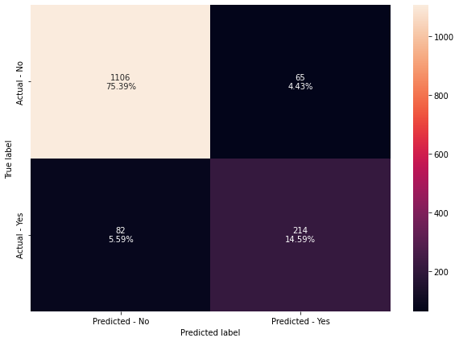

```python
make_confusion_matrix(dt_estimator_tuned,y_test)
```

# Comparing Bagging Models

```python
# defining list of models
models = [bagging_estimator,bagging_estimator_tuned,bagging_lr,rf_estimator,rf_estimator_tuned,
          rf_estimator_weighted,dt_estimator,dt_estimator_tuned]

# defining empty lists to add train and test results
acc_train = []
acc_test = []
recall_train = []
recall_test = []
precision_train = []
precision_test = []
roc_auc_train = []
roc_auc_test = []

# looping through all the models to get the accuracy, precall and precision scores
for model in models:
    j = get_metrics_score(model,False)
    acc_train.append(np.round(j[0],2))
    acc_test.append(np.round(j[1],2))
    recall_train.append(np.round(j[2],2))
    recall_test.append(np.round(j[3],2))
    precision_train.append(np.round(j[4],2))
    precision_test.append(np.round(j[5],2))
    roc_auc_train.append(np.round(j[6],2))
    roc_auc_test.append(np.round(j[7],2))
```

```python
comparison_frame = pd.DataFrame({'Model':['Bagging classifier with default parameters','Tuned Bagging Classifier',
                                        'Bagging classifier with base_estimator=LR', 'Random Forest with deafult parameters',
                                         'Tuned Random Forest Classifier','Random Forest with class_weights',
                                         'Decision Tree classifier with default parameters', 'Tuned Decision Tree Classifier'
                                         ],
                                          'Train_Accuracy': acc_train,'Test_Accuracy': acc_test,
                                          'Train_Recall':recall_train,'Test_Recall':recall_test,
                                          'Train_Precision':precision_train,'Test_Precision':precision_test,
                                          'Train_Roc-Auc':roc_auc_train, 'Test_Roc-Auc':roc_auc_test})
comparison_frame
```

|  | Model | Train_Accuracy | Test_Accuracy | Train_Recall | Test_Recall | Train_Precision | Test_Precision | Train_Roc-Auc | Test_Roc-Auc |
| --- | --- | --- | --- | --- | --- | --- | --- | --- | --- |
| 0 | Bagging classifier with default parameters | 1.00 | 0.91 | 0.98 | 0.62 | 1.00 | 0.89 | 0.99 | 0.80 |
| 1 | Tuned Bagging Classifier | 1.00 | 0.92 | 1.00 | 0.63 | 1.00 | 0.95 | 1.00 | 0.81 |
| 2 | Bagging classifier with base_estimator=LR | 0.85 | 0.83 | 0.30 | 0.26 | 0.68 | 0.72 | 0.63 | 0.62 |
| 3 | Random Forest with deafult parameters | 1.00 | 0.91 | 1.00 | 0.57 | 1.00 | 0.96 | 1.00 | 0.78 |
| 4 | Tuned Random Forest Classifier | 0.92 | 0.85 | 0.56 | 0.35 | 0.95 | 0.81 | 0.78 | 0.67 |
| 5 | Random Forest with class_weights | 0.91 | 0.86 | 0.83 | 0.60 | 0.73 | 0.67 | 0.88 | 0.76 |
| 6 | Decision Tree classifier with default parameters | 1.00 | 0.90 | 1.00 | 0.72 | 1.00 | 0.78 | 1.00 | 0.83 |
| 7 | Tuned Decision Tree Classifier | 1.00 | 0.90 | 1.00 | 0.72 | 1.00 | 0.77 | 1.00 | 0.83 |

# Boosting Models

## AdaBoost Classifier

```python
ab_classifier=AdaBoostClassifier(random_state=1)
ab_classifier.fit(x_train,y_train)
```

```
AdaBoostClassifier(random_state=1)
```

```python
ab_regressor_perf_score = get_metrics_score(ab_classifier)
```

```
Accuracy on training set :  0.8523823443437591
Accuracy on test set :  0.830947511929107
Recall on training set :  0.328525641025641
Recall on test set :  0.2702702702702703
Precision on training set :  0.7044673539518901
Precision on test set :  0.7142857142857143
ROC-AUC on training set :  0.6488892059257629
ROC-AUC on test set :  0.62147159969534
```

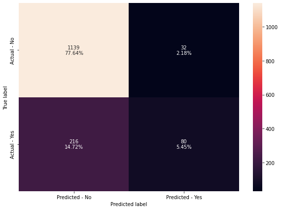

```python
make_confusion_matrix(ab_classifier,y_test)
```

### Hyperparameter Tuning

```python
# Choose the type of classifier.
abc_tuned = AdaBoostClassifier(random_state=1)

# Grid of parameters to choose from
parameters = {
    #Let's try different max_depth for base_estimator
    "base_estimator":[DecisionTreeClassifier(max_depth=1),DecisionTreeClassifier(max_depth=2),
                      DecisionTreeClassifier(max_depth=3)],
    "n_estimators": np.arange(10,110,10),
    "learning_rate":np.arange(0.1,2,0.1)
}

# Type of scoring used to compare parameter  combinations
scorer = metrics.make_scorer(metrics.recall_score)

# Run the grid search
grid_obj = GridSearchCV(abc_tuned, parameters, scoring=scorer,cv=5)
grid_obj = grid_obj.fit(x_train, y_train)

# Set the clf to the best combination of parameters
abc_tuned = grid_obj.best_estimator_

# Fit the best algorithm to the data.
abc_tuned.fit(x_train, y_train)
```

```
AdaBoostClassifier(base_estimator=DecisionTreeClassifier(max_depth=3),
                   learning_rate=1.2000000000000002, n_estimators=100,
                   random_state=1)
```

```python
ab_regressor_perf_score = get_metrics_score(abc_tuned)
```

```
Accuracy on training set :  0.9944460684010523
Accuracy on test set :  0.9079754601226994
Recall on training set :  0.9759615384615384
Recall on test set :  0.6655405405405406
Precision on training set :  0.9934747145187602
Precision on test set :  0.8454935622317596
ROC-AUC on training set :  0.9872657173895106
ROC-AUC on test set :  0.8173987929005009
```

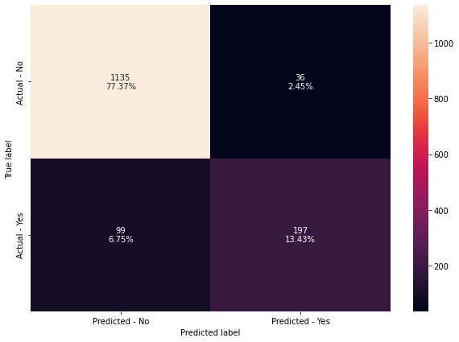

```python
make_confusion_matrix(abc_tuned,y_test)
```

## Gradient Boosting Classifier

```python
#Fitting the model
gb_classifier = GradientBoostingClassifier(random_state=1)
gb_classifier.fit(x_train,y_train)
```

```
GradientBoostingClassifier(random_state=1)
```

```python
gb_classifier_perf_score = get_metrics_score(gb_classifier)
```

```
Accuracy on training set :  0.8877521192633733
Accuracy on test set :  0.8575323790047716
Recall on training set :  0.47275641025641024
Recall on test set :  0.375
Precision on training set :  0.8428571428571429
Precision on test set :  0.8222222222222222
ROC-AUC on training set :  0.7265462423109008
ROC-AUC on test set :  0.6772523484201537
```

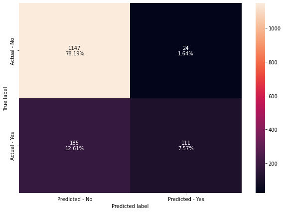

```python
make_confusion_matrix(gb_classifier,y_test)
```

### Hyperparameter Tuning

```python
# Choose the type of classifier.
gbc_tuned = GradientBoostingClassifier(init=AdaBoostClassifier(random_state=1),random_state=1)

# Grid of parameters to choose from
parameters = {
    "n_estimators": [100,150,200,250],
    "subsample":[0.8,0.9,1],
    "max_features":[0.7,0.8,0.9,1]
}

# Type of scoring used to compare parameter combinations
scorer = metrics.make_scorer(metrics.recall_score)

# Run the grid search
grid_obj = GridSearchCV(gbc_tuned, parameters, scoring=scorer,cv=5)
grid_obj = grid_obj.fit(x_train, y_train)

# Set the clf to the best combination of parameters
gbc_tuned = grid_obj.best_estimator_

# Fit the best algorithm to the data.
gbc_tuned.fit(x_train, y_train)
```

```
GradientBoostingClassifier(init=AdaBoostClassifier(random_state=1),
                           max_features=0.8, n_estimators=250, random_state=1,
                           subsample=0.8)
```

```python
gbc_tuned_perf_score = get_metrics_score(gbc_tuned)
```

```
Accuracy on training set :  0.9301373867290266
Accuracy on test set :  0.8786639400136332
Recall on training set :  0.6586538461538461
Recall on test set :  0.46283783783783783
Precision on training set :  0.9405034324942791
Precision on test set :  0.8782051282051282
ROC-AUC on training set :  0.8246790861087429
ROC-AUC on test set :  0.7233061947515406
```

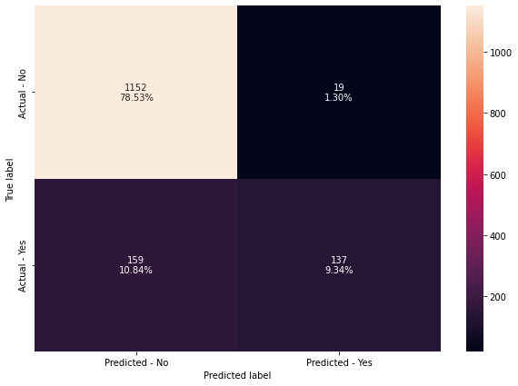

```python
make_confusion_matrix(gbc_tuned,y_test)
```

## XGBoost Classifier

```python
#Fitting the model
xgb_classifier = XGBClassifier(random_state=1, eval_metric='logloss')
xgb_classifier.fit(x_train,y_train)
```

```
XGBClassifier(base_score=0.5, booster='gbtree', callbacks=None,
              colsample_bylevel=1, colsample_bynode=1, colsample_bytree=1,
              early_stopping_rounds=None, enable_categorical=False,
              eval_metric='logloss', gamma=0, gpu_id=-1,
              grow_policy='depthwise', importance_type=None,
              interaction_constraints='', learning_rate=0.300000012,
              max_bin=256, max_cat_to_onehot=4, max_delta_step=0, max_depth=6,
              max_leaves=0, min_child_weight=1, missing=nan,
              monotone_constraints='()', n_estimators=100, n_jobs=0,
              num_parallel_tree=1, predictor='auto', random_state=1,
              reg_alpha=0, reg_lambda=1, ...)
```

```python
xgb_classifier_perf_score = get_metrics_score(xgb_classifier)
```

```
Accuracy on training set :  1.0
Accuracy on test set :  0.9359236537150648
Recall on training set :  1.0
Recall on test set :  0.722972972972973
Precision on training set :  1.0
Precision on test set :  0.9469026548672567
ROC-AUC on training set :  1.0
ROC-AUC on test set :  0.8563626606965633
```

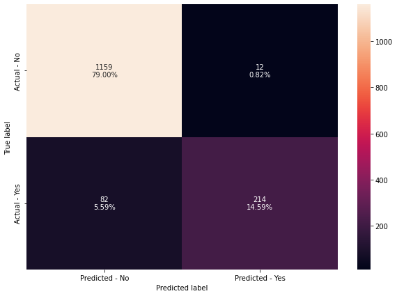

```python
make_confusion_matrix(xgb_classifier,y_test)
```

### Hyperparameter Tuning

```python
# Choose the type of classifier.
xgb_tuned = XGBClassifier(random_state=1, eval_metric='logloss')

# Grid of parameters to choose from
parameters = {
    "n_estimators": [10,30,50],
    "scale_pos_weight":[1,2,5],
    "subsample":[0.7,0.9,1],
    "learning_rate":[0.05, 0.1,0.2],
    "colsample_bytree":[0.7,0.9,1],
    "colsample_bylevel":[0.5,0.7,1]
}

# Type of scoring used to compare parameter combinations
scorer = metrics.make_scorer(metrics.recall_score)

# Run the grid search
grid_obj = GridSearchCV(xgb_tuned, parameters,scoring=scorer,cv=5)
grid_obj = grid_obj.fit(x_train, y_train)

# Set the clf to the best combination of parameters
xgb_tuned = grid_obj.best_estimator_

# Fit the best algorithm to the data.
xgb_tuned.fit(x_train, y_train)
```

```
XGBClassifier(base_score=0.5, booster='gbtree', callbacks=None,
              colsample_bylevel=0.5, colsample_bynode=1, colsample_bytree=0.9,
              early_stopping_rounds=None, enable_categorical=False,
              eval_metric='logloss', gamma=0, gpu_id=-1,
              grow_policy='depthwise', importance_type=None,
              interaction_constraints='', learning_rate=0.2, max_bin=256,
              max_cat_to_onehot=4, max_delta_step=0, max_depth=6, max_leaves=0,
              min_child_weight=1, missing=nan, monotone_constraints='()',
              n_estimators=30, n_jobs=0, num_parallel_tree=1, predictor='auto',
              random_state=1, reg_alpha=0, reg_lambda=1, ...)
```

```python
xgb_tuned_perf_score = get_metrics_score(xgb_tuned)
```

```
Accuracy on training set :  0.9339374451914645
Accuracy on test set :  0.8738922972051807
Recall on training set :  0.9535256410256411
Recall on test set :  0.7601351351351351
Precision on training set :  0.7512626262626263
Precision on test set :  0.6637168141592921
ROC-AUC on training set :  0.9415465173308397
ROC-AUC on test set :  0.8313912225632977
```

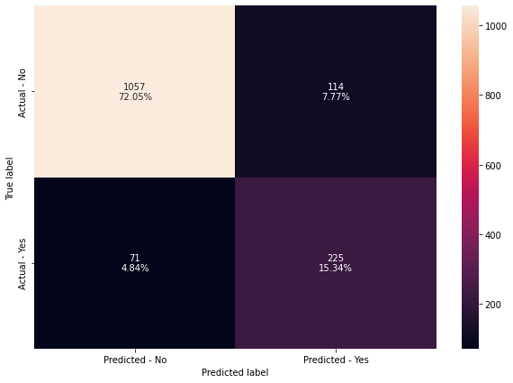

```python
make_confusion_matrix(xgb_tuned,y_test)
```

## Stacking Classifier

```python
estimators = [('Random Forest',rf_estimator_tuned), ('Gradient Boosting',gbc_tuned), ('Decision Tree',dt_estimator_tuned)]

final_estimator = xgb_tuned

stacking_classifier= StackingClassifier(estimators=estimators,final_estimator=final_estimator)

stacking_classifier.fit(x_train,y_train)
```

```
StackingClassifier(estimators=[('Random Forest',
                                RandomForestClassifier(max_features=0.6000000000000001,
                                                       max_samples=0.6000000000000001,
                                                       min_samples_leaf=5,
                                                       n_estimators=200,
                                                       random_state=1)),
                               ('Gradient Boosting',
                                GradientBoostingClassifier(init=AdaBoostClassifier(random_state=1),
                                                           max_features=0.8,
                                                           n_estimators=250,
                                                           random_state=1,
                                                           subsample=0.8)),
                               ('Decision Tr...
                                                 eval_metric='logloss', gamma=0,
                                                 gpu_id=-1,
                                                 grow_policy='depthwise',
                                                 importance_type=None,
                                                 interaction_constraints='',
                                                 learning_rate=0.2, max_bin=256,
                                                 max_cat_to_onehot=4,
                                                 max_delta_step=0, max_depth=6,
                                                 max_leaves=0,
                                                 min_child_weight=1,
                                                 missing=nan,
                                                 monotone_constraints='()',
                                                 n_estimators=30, n_jobs=0,
                                                 num_parallel_tree=1,
                                                 predictor='auto',
                                                 random_state=1, reg_alpha=0,
                                                 reg_lambda=1, ...))
```

```python
stacking_classifier_perf_score = get_metrics_score(stacking_classifier)
```

```
Accuracy on training set :  0.9529377375036538
Accuracy on test set :  0.8936605316973415
Recall on training set :  1.0
Recall on test set :  0.8682432432432432
Precision on training set :  0.7949044585987262
Precision on test set :  0.6871657754010695
ROC-AUC on training set :  0.9712191633893457
ROC-AUC on test set :  0.8841643201698709
```

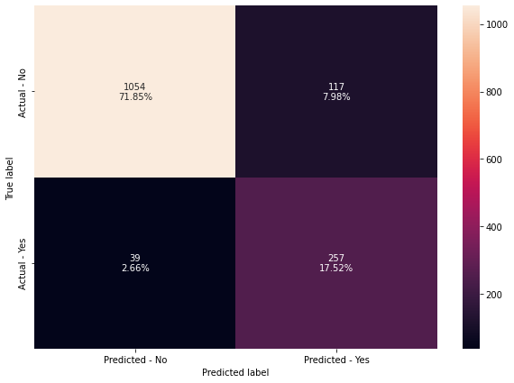

```python
make_confusion_matrix(stacking_classifier,y_test)
```